# Bay Area Assignment 2

Emma Clark

12/1/2020

## Part 1: Equity Analysis of Educational Attainment by Race

```r
# race labels
census_race_labels <-
  c(
    "White Alone",
    "Black or African American",
    "American Indian and Alaska Native Alone",
    "Asian Alone",
    "Native Hawaiian and Other Pacific Islander Alone)",
    "Some Other Race Alone",
    "Two or More Races"
  )

# education attainment by race __ county
SF_educ_attain_race <-
  1:7 %>%
  map_dfr(function(x){
    getCensus(
      name = "acs/acs5",
      vintage = 2018,
      region = "county:075",
      regionin = "state:06",
      vars = paste0("group(C15002",LETTERS[x],")")
    ) %>%
      select(!c(GEO_ID,state,NAME) & !ends_with(c("EA","MA","M"))) %>%
      pivot_longer(
        ends_with("E"),
        names_to = "variable",
        values_to = "estimate"
      ) %>%
      left_join(
        acs_vars_2018_5yr %>%
          select(name, label),
        by = c("variable" = "name")
      ) %>%
      select(-variable) %>%
      separate(
        label,
        into = c(NA,NA,NA,"attainment"),
        sep = "!!"
      ) %>%
      filter(!is.na(attainment)) %>%
      mutate(race = census_race_labels[x])
  })
```

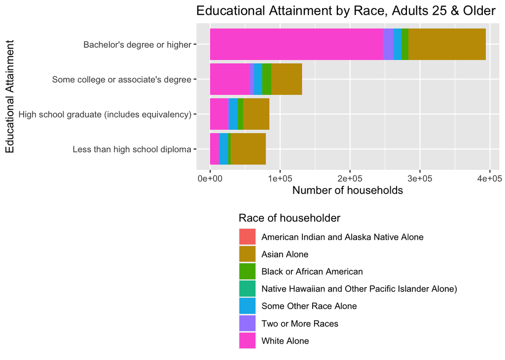

```r
# total counts of householders in this sample by race
bay_educ_total <-
  SF_educ_attain_race %>%
  group_by(race) %>%
  summarize(estimate = sum(estimate)) %>%
  mutate(attainment = "Total")


# stacked bar chart
SF_educ_attain_race %>%
  group_by(attainment, race) %>%
  summarize(estimate = sum(estimate)) %>%
  ggplot() +
  geom_bar(
    aes(
      x = attainment %>% factor(levels = SF_educ_attain_race$attainment[1:4]),
      y = estimate,
      fill = race
    ),
    stat = "identity",
    position = "stack"
  ) +
  labs(
    x = "Educational Attainment",
    y = "Number of households",
    title = "Educational Attainment by Race, Adults 25 & Older",
    fill = "Race of householder"
  ) +
  coord_flip() +
theme(
    legend.position = "bottom",
    legend.direction = "vertical"
  )
```

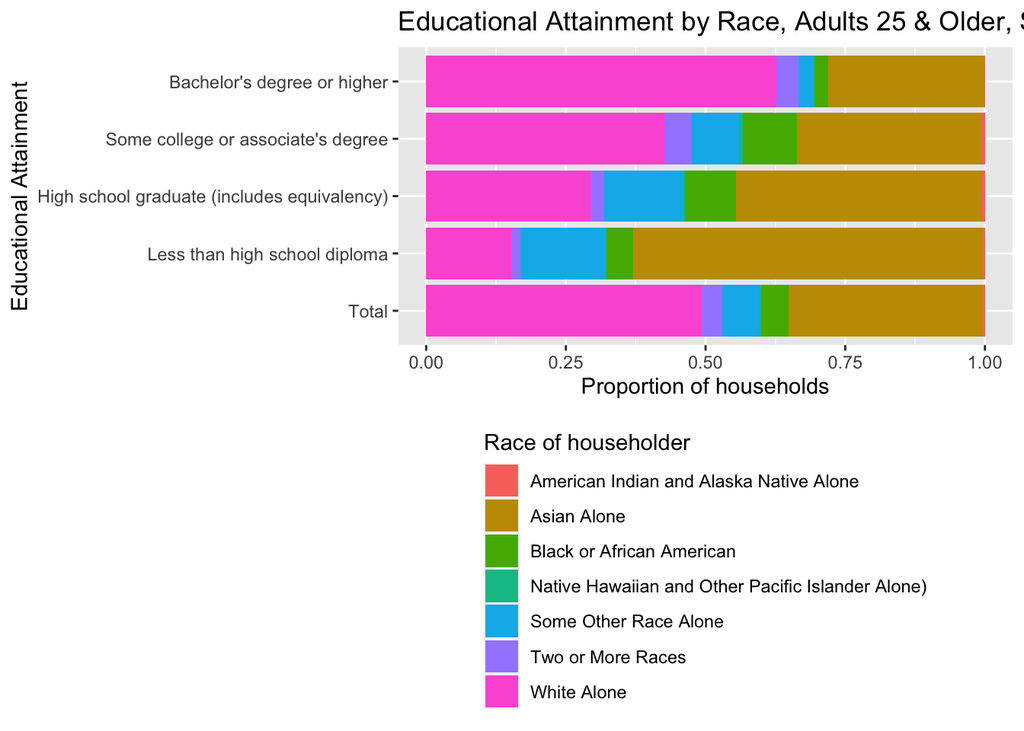

```r
# filled bar chart
SF_educ_attain_race %>%
  group_by(attainment, race) %>%
  summarize(estimate = sum(estimate)) %>%
  rbind(bay_educ_total) %>%
  ggplot() +
  geom_bar(
    aes(
      x = attainment %>% factor(levels = c("Total",SF_educ_attain_race$attainment[1:4])),
      y = estimate,
      fill = race
    ),
    stat = "identity",
    position = "fill"
  ) +
  labs(
    x = "Educational Attainment",
    y = "Proportion of households",
    title = "Educational Attainment by Race, Adults 25 & Older, San Francisco County",
    fill = "Race of householder"
  ) +
  coord_flip() +
theme(
    legend.position = "bottom",
    legend.direction = "vertical"
  )
```

```r
# tabular analysis

# percent non-white
((sum(bay_educ_total$estimate[1:6])/sum(bay_educ_total$estimate))*100) %>% round()
```

```
## [1] 51
```

```r
# percent non-white for attainment = less than high school diploma
((SF_educ_attain_race %>%
  filter(SF_educ_attain_race$attainment == "Less than high school diploma") %>%
  filter(race != "White Alone") %>%
  pull(estimate) %>%
  sum()) /
  (SF_educ_attain_race %>%
    filter(SF_educ_attain_race$attainment == "Less than high school diploma") %>%
    pull(estimate) %>%
    sum()) * 100) %>%
  round()
```

```
## [1] 85
```

```r
# how much more likely are non-white households to have less than a high school degree than non-white households
((85-51) / 51)
```

```
## [1] 0.6666667
```

Based on this analysis, there appears to be disproportionate education attainment by race in this county. Visually, the distribution by race of each level of educational attainment does not match the expected distribution based on the total distribution of race. That is, if education attainment was proportional, we would expect the education attainment by race to match the population distribution of race at each education level. Instead, we see varying degrees of dissonance with the population distribution at each education level.

For example, the overall population in San Francisco County is 51% non-White, but the subpopulation of householders with less than a high school diploma is 85% non-white. This means that non-White households are 66% more likely to have less than a high school diploma than White households.

## Part 2: Percent of K-12 Students without Internet Access

```r
# get pums data & create data dictionary
census_api_key("f5de96c4281405d5f6bfedbbca1bc17d50fb8e23")

pums_vars_2018 <-
  pums_variables %>%
  filter(year == 2018, survey == "acs1")

pums_vars_2018_distinct_hh <-
  pums_vars_2018 %>%
  distinct(var_code, var_label, data_type, level) %>%
  filter(level == "housing")
```

```r
# bay county names
bay_county_names <-
  c(
    "Alameda",
    "Contra Costa",
    "Marin",
    "Napa",
    "San Francisco",
    "San Mateo",
    "Santa Clara",
    "Solano",
    "Sonoma"
  )

bay_counties <-
  counties("CA", cb = T, progress_bar = F) %>%
  filter(NAME %in% bay_county_names)

# sf county name
sf_county_name <- "San Francisco"

sf_county <-
  counties("CA", cb = T, progress_bar = F) %>%
  filter(NAME %in% sf_county_name)
```

```r
# ca pums (survey data)
ca_pums <- get_pums(
  variables = c(
    "PUMA",
    "ACCESS",
    "SCHG"),
  state = "CA",
  year = 2019,
  survey = "acs1",
  recode = T)

# filter to pumas in Bay Area
ca_pumas <- pumas("CA", cb = T, progress_bar = F)

bay_pumas <-
  ca_pumas %>%
  st_centroid() %>%
  .[bay_counties, ] %>%
  st_set_geometry(NULL) %>%
  left_join(ca_pumas %>% select(GEOID10)) %>%
  st_as_sf()

# Bay Area subdata
bay_pums <-
  ca_pums %>%
  filter(PUMA %in% bay_pumas$PUMACE10)

# filter to pumas in San Francisco county
sf_pumas <-
  bay_pumas %>%
  st_centroid() %>%
  .[sf_county, ] %>%
  st_set_geometry(NULL) %>%
  left_join(bay_pumas %>% select(GEOID10)) %>%
  st_as_sf()

# San Francisco county subdata
sf_pums <-
  bay_pums %>%
  filter(PUMA %in% sf_pumas$PUMACE10)
```

```r
# San Francisco county percent k12 students no internet access
sf_pums_k12_internet <-
  sf_pums %>%
  mutate(SCHG = as.numeric (SCHG)) %>%
  filter(SCHG %in% 2:14) %>%
  mutate(no_access = ifelse(ACCESS == "3", PWGTP, 0)) %>%
  group_by(PUMA) %>%
  summarize(
    pct_student_no_access =
      sum(no_access, na.rm =T)/sum(PWGTP, na.rm = T)*100) %>%
  left_join(
    sf_pumas %>%
      select(PUMACE10),
    by = c("PUMA" = "PUMACE10")
  ) %>%
  st_as_sf()
```

```r
# Bay Area percent k12 students without internet access
bay_pums_k12_internet <-
  bay_pums %>%
  mutate(SCHG = as.numeric (SCHG)) %>%
  filter(SCHG %in% 2:14) %>%
  mutate(no_access = ifelse(ACCESS == "3", PWGTP, 0)) %>%
  group_by(PUMA) %>%
  summarize(
    pct_student_no_access =
      sum(no_access, na.rm =T)/sum(PWGTP, na.rm = T)*100) %>%
  left_join(
    bay_pumas %>%
      select(PUMACE10),
    by = c("PUMA" = "PUMACE10")
  ) %>%
  st_as_sf()

# average percent of k12 students without access across bay area
bay_k12 <- bay_pums %>%
  mutate(SCHG = as.numeric (SCHG)) %>%
  filter(SCHG %in% 2:14) %>%
  mutate(no_access = ifelse(ACCESS == "3", PWGTP, 0))

av_pct <- sum(bay_k12$no_access) / sum(bay_k12$PWGTP)
av_pct
```

```
## [1] 0.02388246
```

```r
sum(bay_k12$no_access)
```

```
## [1] 27419
```

```r
# map percent k-12 students without internet access whole Bay Area
pums_pal <- colorNumeric(
  palette = "Oranges",
  domain = bay_pums_k12_internet$pct_student_no_access
)

leaflet() %>%
  addTiles() %>%
  addPolygons(
    data = bay_pums_k12_internet,
    fillColor = ~pums_pal(pct_student_no_access),
    color = "white",
    opacity = 0.5,
    fillOpacity = 0.5,
    weight = 1,
    label = ~paste0(pct_student_no_access,
      "% k-12 students without internet access"
    ),
    highlightOptions = highlightOptions(
      weight = 2,
      opacity = 1
    )
  ) %>%
  addLegend(
    data = bay_pums_k12_internet,
    pal = pums_pal,
    values = ~pct_student_no_access,
    title = "Percent k-12 students<br>without internet access<br>2018"
  )
```

[interactive chart not shown]

An average of 2.4% of k-12 children in the Bay Area do not have internet access, this is roughly 27,419 children. Assuming that some of this internet access is unreliable or inadequate, the true number of k-12 students unable to complete schooling remotely could be much higher. Further, one can see that the percent without access is most concentrated in a relatively small area near Oakland. This could pose a significant challenge since many of those students would attend the same schools and so the strain on necessary resources would be similarly concentrated in this area.

## Part 3: Migration Analysis

```r
acs_vars_2019_1yr <-
  listCensusMetadata(
    name = "2019/acs/acs1",
    type = "variables")

# San Francisco county, current geographic mobility by education
sfc_mobility_current_19 <-
  getCensus(
    name = "acs/acs1",
    vintage = 2019,
    region = "county:075",
    regionin = "state:06",
    vars = c("group(B07009)")
  ) %>%
  select(!c(GEO_ID,state,NAME) & !ends_with(c("EA","MA","M"))) %>%
  pivot_longer(
    ends_with("E"),
    names_to = "variable",
    values_to = "estimate"
  ) %>%
  left_join(
    acs_vars_2019_1yr %>%
      select(name, label),
    by = c("variable" = "name")
  ) %>%
  select(-variable) %>%
  separate(
    label,
    into = c(NA,NA,"mobility","education"),
    sep = "!!"
  ) %>%
  mutate(
    mobility = ifelse(
      mobility %in% c("Same house 1 year ago:", "Moved within same county:"),
      "Here since last year",
      "Inflow"
    )
  ) %>%
  filter(!is.na(education)) %>%
  group_by(mobility, education) %>%
  summarize(estimate = sum(estimate))

# San Francisco county, last year geographic mobility by education
sfc_mobility_lastyear_19 <-
  getCensus(
    name = "acs/acs1",
    vintage = 2019,
    region = "county:075",
    regionin = "state:06",
    vars = c("group(B07409)")
  ) %>%
  select(!c(GEO_ID,state,NAME) & !ends_with(c("EA","MA","M"))) %>%
  pivot_longer(
    ends_with("E"),
    names_to = "variable",
    values_to = "estimate"
  ) %>%
  left_join(
    acs_vars_2019_1yr %>%
      select(name, label),
    by = c("variable" = "name")
  ) %>%
  select(-variable) %>%
  separate(
    label,
    into = c(NA,NA,"mobility","education"),
    sep = "!!"
  ) %>%
  mutate(
    mobility = ifelse(
      mobility %in% c("Same house:", "Moved within same county:"),
      "Here since last year",
      "Outflow"
    )
  ) %>%
  filter(!is.na(education)) %>%
  group_by(mobility, education) %>%
  summarize(estimate = sum(estimate))

# total counts from 2018
sfc_mobility_current_18 <-
  getCensus(
    name = "acs/acs1",
    vintage = 2018,
    region = "county:075",
    regionin = "state:06",
    vars = c("group(B07009)")
  ) %>%
  select(!c(GEO_ID,state,NAME) & !ends_with(c("EA","MA","M"))) %>%
  pivot_longer(
    ends_with("E"),
    names_to = "variable",
    values_to = "estimate"
  ) %>%
  left_join(
    acs_vars_2019_1yr %>%
      select(name, label),
    by = c("variable" = "name")
  ) %>%
  select(-variable) %>%
  separate(
    label,
    into = c(NA,NA,"mobility","education"),
    sep = "!!"
  ) %>%
  mutate(
    mobility = "Here last year"
  ) %>%
  filter(!is.na(education)) %>%
  group_by(mobility, education) %>%
  summarize(estimate = sum(estimate))
```

```r
# bind dataframes and create internal and external flow fields
sfc_flows_19 <-
  rbind(
    sfc_mobility_current_18,
    sfc_mobility_lastyear_19 %>%
      filter(mobility == "Outflow"),
    sfc_mobility_current_19 %>%
      filter(mobility == "Inflow"),
    sfc_mobility_current_19 %>%
      group_by(education) %>%
      summarize(estimate = sum(estimate)) %>%
      mutate(mobility = "Here this year")
  ) %>%
  pivot_wider(
    names_from = mobility,
    values_from = estimate
  ) %>%
  mutate(
    `External net` = Inflow - Outflow,
    `Internal net` = `Here this year` - `Here last year` - `External net`,
  ) %>%
  select(
    `Education` = education,
    `Internal net`,
    `External net`,
    `Here last year`,
    `Here this year`,
    Outflow,
    Inflow
  )

sfc_flows_19
```

```
## # A tibble: 5 x 7
##   Education `Internal net` `External net` `Here last year` `Here this year`
##   <chr>              <dbl>          <dbl>            <dbl>            <dbl>
## 1 Bachelor…           -828          -6881           253594           245885
## 2 Graduate…           3938          -1435           166736           169239
## 3 High sch…          -3363            792            85850            83279
## 4 Less tha…          10171          -2013            73381            81539
## 5 Some col…            823          -2490           123004           121337
## # … with 2 more variables: Outflow <dbl>, Inflow <dbl>
```

To what degree is there an increase in education compared to displacement of different education groups? The internal net flow measure encompasses births and deaths of individuals in that education level along with new entrants and individuals who have gained higher education. The large internal net outflow of high school graduates suggests that many high school graduates in the area have moved to a higher education level. The internal flow of +3938 for graduate of professional degree also confirms an increase of education level for indivudals in the area. Individuals of almost every education level are a net outflow, so there doesn’t appear to be displacement of less educated groups by more educated. The only group with a positive external net migration is high school graduates, perhaps recent graduates moving to the area for college.